# 9_2_cross_valadation

Author

Alexa Marin

# Training and Test Errors, Cross-Validation, Pipelines

```python
import pandas as pd
import numpy as np

from plotnine import *
```

**Use scikit-learn, including pipelines, whenever possible.**

## Ames Housing Data

We have fit different regression models to predict house prices (SalePrice, not log). Now we will evaluate models by estimating their prediction error.

```python
df_ames = pd.read_csv("http://dlsun.github.io/pods/data/AmesHousing.txt", sep = "\t")

df_ames
```

|  | Order | PID | MS SubClass | MS Zoning | Lot Frontage | Lot Area | Street | Alley | Lot Shape | Land Contour | ... | Pool Area | Pool QC | Fence | Misc Feature | Misc Val | Mo Sold | Yr Sold | Sale Type | Sale Condition | SalePrice |
| --- | --- | --- | --- | --- | --- | --- | --- | --- | --- | --- | --- | --- | --- | --- | --- | --- | --- | --- | --- | --- | --- |
| 0 | 1 | 526301100 | 20 | RL | 141.0 | 31770 | Pave | NaN | IR1 | Lvl | ... | 0 | NaN | NaN | NaN | 0 | 5 | 2010 | WD | Normal | 215000 |
| 1 | 2 | 526350040 | 20 | RH | 80.0 | 11622 | Pave | NaN | Reg | Lvl | ... | 0 | NaN | MnPrv | NaN | 0 | 6 | 2010 | WD | Normal | 105000 |
| 2 | 3 | 526351010 | 20 | RL | 81.0 | 14267 | Pave | NaN | IR1 | Lvl | ... | 0 | NaN | NaN | Gar2 | 12500 | 6 | 2010 | WD | Normal | 172000 |
| 3 | 4 | 526353030 | 20 | RL | 93.0 | 11160 | Pave | NaN | Reg | Lvl | ... | 0 | NaN | NaN | NaN | 0 | 4 | 2010 | WD | Normal | 244000 |
| 4 | 5 | 527105010 | 60 | RL | 74.0 | 13830 | Pave | NaN | IR1 | Lvl | ... | 0 | NaN | MnPrv | NaN | 0 | 3 | 2010 | WD | Normal | 189900 |
| ... | ... | ... | ... | ... | ... | ... | ... | ... | ... | ... | ... | ... | ... | ... | ... | ... | ... | ... | ... | ... | ... |
| 2925 | 2926 | 923275080 | 80 | RL | 37.0 | 7937 | Pave | NaN | IR1 | Lvl | ... | 0 | NaN | GdPrv | NaN | 0 | 3 | 2006 | WD | Normal | 142500 |
| 2926 | 2927 | 923276100 | 20 | RL | NaN | 8885 | Pave | NaN | IR1 | Low | ... | 0 | NaN | MnPrv | NaN | 0 | 6 | 2006 | WD | Normal | 131000 |
| 2927 | 2928 | 923400125 | 85 | RL | 62.0 | 10441 | Pave | NaN | Reg | Lvl | ... | 0 | NaN | MnPrv | Shed | 700 | 7 | 2006 | WD | Normal | 132000 |
| 2928 | 2929 | 924100070 | 20 | RL | 77.0 | 10010 | Pave | NaN | Reg | Lvl | ... | 0 | NaN | NaN | NaN | 0 | 4 | 2006 | WD | Normal | 170000 |
| 2929 | 2930 | 924151050 | 60 | RL | 74.0 | 9627 | Pave | NaN | Reg | Lvl | ... | 0 | NaN | NaN | NaN | 0 | 11 | 2006 | WD | Normal | 188000 |

2930 rows × 82 columns

Since all of the houses in the data set have a SalePrice, we’ll include all the observations in the training data. We’ll start with a basic linear regression model with a few features.

```python
X_train = df_ames[["Gr Liv Area", "Bedroom AbvGr", "Full Bath", "Half Bath"]]

y_train = df_ames["SalePrice"]
```

```python
from sklearn.linear_model import LinearRegression

model1 = LinearRegression()
model1.fit(
    X=X_train,
    y=y_train
)
```

```
LinearRegression()
```

1. Explain conceptually what the “fit” step does. What is the output?

The fit step uses the training data to find the regression coefficients that make the predicted SalePrice values as close as possible to the actual SalePrice values. The output is a fitted linear regression model with an intercept and one coefficient for each feature.

2. Explain conceptually how you would compute the *training* RMSE (root mean square error) of this model.

I would use the fitted model to predict SalePrice for every house in the training data, find each prediction error, square the errors, average them, and take the square root.

3. Interpret the *training RMSE*. Is it big or small? What could you use as a rough benchmark for comparison?

Training RMSE is the typical dollar amount the model is off for the houses it was trained on. I would compare it to the standard deviation of SalePrice, or to a basic model that always predicts the mean SalePrice.

4. Suppose we add more features like “TotRms AbvGrd” and fit a new model. Would the *training* RMSE increase or decrease? Why is comparing the *training* RMSE of these two models not useful?

Training RMSE can only decrease or stay the same after adding features because the new model has more flexibility. Comparing training RMSE is not useful because a more complicated model can look better on its own training data even if it does not predict new houses better.

5. If we fit a 1-nearest neighbor model, what should the *training* RMSE be?

A 1-nearest-neighbors model has a training RMSE of 0 because every training house is its own closest neighbor, so it predicts its own actual SalePrice.

6. What happens to the *training* RMSE of a $k$-nearest neighbors model as $k$ increases?

As k increases, training RMSE increases or stays the same. The model averages more homes together and does not fit each training house as closely.

7. We are really interested in the *test* RMSE, not the *training* RMSE. Explain why in practice you can not compute the *test* RMSE.

We cannot calculate the true test RMSE because it requires the actual SalePrice for new houses the model has never seen. In real life, those future houses and their prices are not available yet.

8. Explain conceptually how cross-validations *estimates* the *test* RMSE.

Cross-validation splits the data into folds. It fits the model on most folds, predicts the held-out fold, and repeats this until every observation has been held out once. The RMSE from those held-out predictions estimates test RMSE

9. We’ll use cross-validation to estimate the *test* RMSE for the model from part 1. Will the *test* RMSE be greater than, less than, or equal to the *training* RMSE for this model?

Test RMSE should be greater than training RMSE because the model has already seen the training homes, while the test predictions are for homes it did not use to fit the model.

10. Suppose we add features like we did in part 4. Will the *test* RMSE necessarily decrease? Fit the test RMSE and compare the two models - which is better based on this criteria?

Test RMSE does not necessarily decrease when we add features. Extra features can help, but they can also cause overfitting. I would choose the model with the lower cross-validated RMSE.

11. Now suppose we add a categorical predictor like Neighborhood. The crossval code below will (probably) error. Explain why. Hint: think about how the cross-validation process works and how categorical variables are treated.

The categorical Neighborhood variable has to be changed into dummy variables. During cross-validation, a category can appear in a test fold but not in that fold’s training data, which can cause an error with the default one-hot encoder. handle_unknown=“ignore” fixes that.

```python
from sklearn.compose import ColumnTransformer
from sklearn.preprocessing import OneHotEncoder, StandardScaler
from sklearn.pipeline import Pipeline
from sklearn.neighbors import KNeighborsRegressor

ct = ColumnTransformer(
    [("standardize", StandardScaler(), ["Gr Liv Area", "Bedroom AbvGr", "Full Bath", "Half Bath"],),
     ("dummify", OneHotEncoder(), ["Neighborhood"]),
    ],
    remainder="drop",
)

neighborhood_model = Pipeline(
    [("preprocessing", ct),
     ("lm", LinearRegression())]
)

X_train = df_ames[["Gr Liv Area", "Bedroom AbvGr", "Full Bath", "Half Bath", "Neighborhood"]]
y_train = df_ames["SalePrice"]

neighborhood_model.fit(X_train, y_train)
```

```
Pipeline(steps=[('preprocessing',
                 ColumnTransformer(transformers=[('standardize',
                                                  StandardScaler(),
                                                  ['Gr Liv Area',
                                                   'Bedroom AbvGr', 'Full Bath',
                                                   'Half Bath']),
                                                 ('dummify', OneHotEncoder(),
                                                  ['Neighborhood'])])),
                ('lm', LinearRegression())])
```

```python
from sklearn.model_selection import cross_val_score
```

```python
scores = cross_val_score(neighborhood_model,
                         X = X_train,
                         y = y_train,
                         scoring="neg_mean_squared_error",
                         cv=10)
scores
```

[output not shown]

[output cut: 8 more lines]

[output not shown]

```
array([-1.44545804e+09, -2.17595093e+09, -1.03959086e+09, -1.75337709e+09,
       -1.09461084e+09, -2.46145214e+09, -1.41979135e+09, -2.32075632e+09,
       -1.21633500e+09,             nan])
```

11. Going back to part 1, suppose we had standardized the features first. Would the coeffiecients of the fitted model change? Would the *training* RMSE change?

Yes, the coefficients would change because the features are now on the same standardized scale instead of their original units. The training RMSE would stay the same because standardizing changes the scale of the inputs, not the model’s ability to make the same predictions.

12. Suppose we want to standardize predictors like in the previous part and estimate test RMSE using cross-validation. Explain how standardization fits in in the CV process. Also explain why it is important to put standardization as part of the model pipeline.

In cross-validation, standardization should be fit using only the training folds. Then, that scaler is used to standardize both the training fold and the held-out test fold. It is important to put the scaler inside the pipeline so the test fold does not affect the mean or standard deviation used for scaling. This prevents data leakage and gives a more honest estimate of test RMSE.

## Practice Activity

We’ll continue with the housing data and our goal of predicting Sale Price.

We will have a competition to see who can come up with the model with the smallest *test* RMSE. Fit several models and try to find the smallest *test* RMSE. Use cross-validation to estimate the *test* RMSE. When you think you have a good model, share your it and its test RMSE with a partner. Then see what other people have done; can you do even better?

Note: next week we will see how to make some of these choices in a more automated way. For now just work by trial and error. You should try:

- Exploring the data first! Make some plots and summaries to get an idea of what might be good predictors to try
- Several different sets of predictors, including both categorical and numerical predictors
- Linear regression models, including models with polynomial features and interactions
- K-nearest neighbors models, inclduing different values of k
- Decision trees, including different sizes of trees

Use pipelines as much as possible, and don’t forget to transform variables as needed.

### Exploring the data

First I look at the distribution of SalePrice and which numeric variables are most correlated with it.

```python
df_ames["SalePrice"].describe()
```

```
count      2930.000000
mean     180796.060068
std       79886.692357
min       12789.000000
25%      129500.000000
50%      160000.000000
75%      213500.000000
max      755000.000000
Name: SalePrice, dtype: float64
```

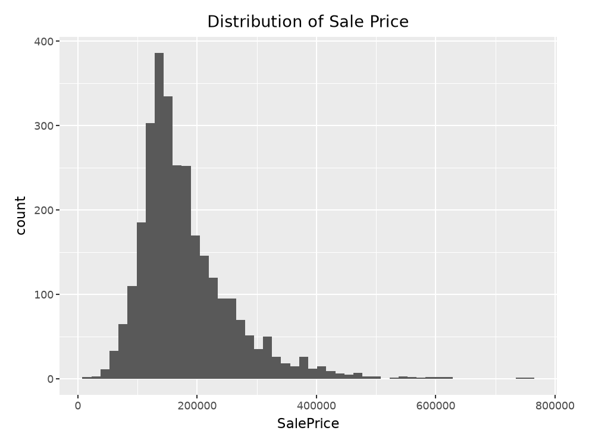

```python
(ggplot(df_ames, aes(x="SalePrice"))
 + geom_histogram(bins=50)
 + labs(title="Distribution of Sale Price"))
```

```python
num_cols = df_ames.select_dtypes("number").drop(columns=["Order", "PID", "SalePrice"])
num_cols.corrwith(df_ames["SalePrice"]).sort_values(ascending=False).head(12)
```

```
Overall Qual      0.799262
Gr Liv Area       0.706780
Garage Cars       0.647877
Garage Area       0.640401
Total Bsmt SF     0.632280
1st Flr SF        0.621676
Year Built        0.558426
Full Bath         0.545604
Year Remod/Add    0.532974
Garage Yr Blt     0.526965
Mas Vnr Area      0.508285
TotRms AbvGrd     0.495474
dtype: float64
```

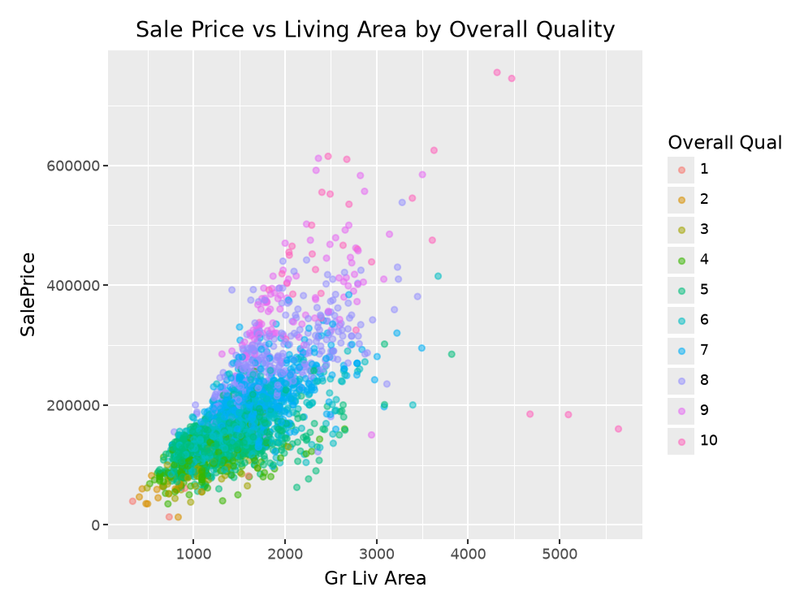

```python
plot_df = df_ames.assign(OverallQual=df_ames["Overall Qual"].astype("category"))

(ggplot(plot_df, aes(x="Gr Liv Area", y="SalePrice", color="OverallQual"))
 + geom_point(alpha=0.5)
 + labs(color="Overall Qual", title="Sale Price vs Living Area by Overall Quality"))
```

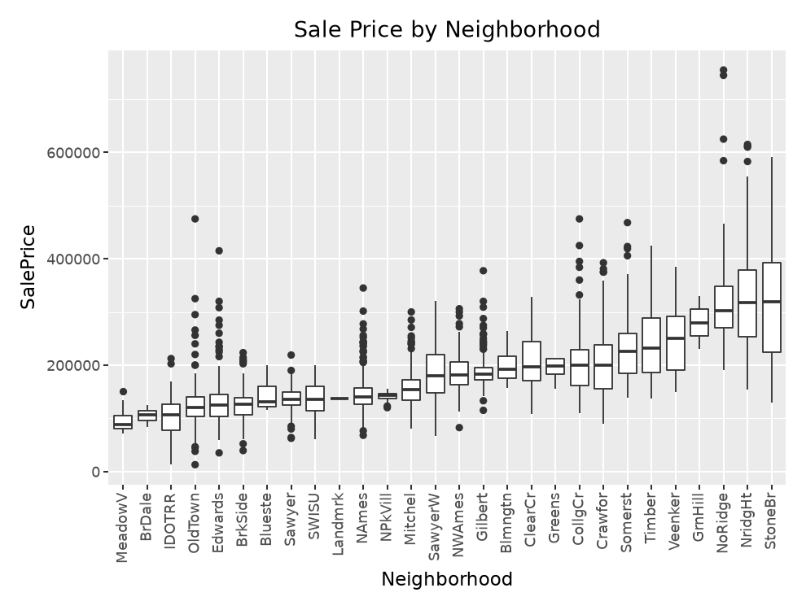

```python
(ggplot(df_ames, aes(x="reorder(Neighborhood, SalePrice)", y="SalePrice"))
 + geom_boxplot()
 + theme(axis_text_x=element_text(rotation=90))
 + labs(x="Neighborhood", title="Sale Price by Neighborhood"))
```

SalePrice is right-skewed, with a mean around $181,000 and a standard deviation around $80,000. That standard deviation is a useful benchmark: a model that always predicts the mean would be off by about $80,000. Overall Qual and Gr Liv Area have the strongest correlations with price, followed by garage size, basement size, and age. The scatterplot also suggests the effect of living area gets steeper at higher quality levels, which hints that an interaction or polynomial term could help. Prices also vary a lot by Neighborhood, so it is worth including as a categorical predictor.

### Setup

I use 10-fold cross-validation with shuffling so every model is evaluated on the same folds. The helper function returns the average cross-validated RMSE. Missing values are imputed inside the pipeline, and the one-hot encoder uses `handle_unknown="ignore"` so rare categories do not break CV.

```python
from sklearn.compose import ColumnTransformer
from sklearn.preprocessing import OneHotEncoder, StandardScaler, PolynomialFeatures
from sklearn.pipeline import Pipeline, make_pipeline
from sklearn.impute import SimpleImputer
from sklearn.linear_model import LinearRegression
from sklearn.neighbors import KNeighborsRegressor
from sklearn.tree import DecisionTreeRegressor
from sklearn.model_selection import cross_val_score, KFold

y = df_ames["SalePrice"]
cv = KFold(n_splits=10, shuffle=True, random_state=1)

def cv_rmse(model, X):
    mse = -cross_val_score(model, X, y, scoring="neg_mean_squared_error", cv=cv)
    return np.sqrt(mse).mean()

def make_ct(num_vars, cat_vars, degree=None):
    num_steps = [SimpleImputer(strategy="median")]
    if degree:
        num_steps.append(PolynomialFeatures(degree, include_bias=False))
    num_steps.append(StandardScaler())
    return ColumnTransformer([
        ("num", make_pipeline(*num_steps), num_vars),
        ("cat", make_pipeline(SimpleImputer(strategy="most_frequent"),
                              OneHotEncoder(handle_unknown="ignore")), cat_vars),
    ])

base_vars = ["Gr Liv Area", "Bedroom AbvGr", "Full Bath", "Half Bath"]
num_vars = ["Overall Qual", "Gr Liv Area", "Total Bsmt SF", "Garage Cars", "Year Built",
            "Year Remod/Add", "1st Flr SF", "Full Bath", "Fireplaces", "Lot Area",
            "Mas Vnr Area", "BsmtFin SF 1"]
cat_vars = ["Neighborhood", "Kitchen Qual", "Exter Qual", "Bsmt Qual", "MS Zoning", "Sale Condition"]

results = {}
```

### Linear regression with different predictor sets

```python
results["LR: base 4 vars"] = cv_rmse(
    Pipeline([("prep", make_ct(base_vars, [])), ("lm", LinearRegression())]),
    df_ames[base_vars])

results["LR: base + Neighborhood"] = cv_rmse(
    Pipeline([("prep", make_ct(base_vars, ["Neighborhood"])), ("lm", LinearRegression())]),
    df_ames[base_vars + ["Neighborhood"]])

results["LR: 12 numeric vars"] = cv_rmse(
    Pipeline([("prep", make_ct(num_vars, [])), ("lm", LinearRegression())]),
    df_ames[num_vars])

results["LR: numeric + categorical"] = cv_rmse(
    Pipeline([("prep", make_ct(num_vars, cat_vars)), ("lm", LinearRegression())]),
    df_ames[num_vars + cat_vars])

results
```

```
{'LR: base 4 vars': np.float64(51181.637296306704),
 'LR: base + Neighborhood': np.float64(39526.52427778985),
 'LR: 12 numeric vars': np.float64(34167.576997491604),
 'LR: numeric + categorical': np.float64(29178.677998592717)}
```

### Polynomial features and interactions

First I apply degree-2 polynomial features to all numeric predictors. Then I try a more targeted version that only expands the five strongest predictors, which keeps the model from adding too many noisy terms.

```python
results["LR: poly2 on all numeric"] = cv_rmse(
    Pipeline([("prep", make_ct(num_vars, cat_vars, degree=2)), ("lm", LinearRegression())]),
    df_ames[num_vars + cat_vars])

key_vars = ["Overall Qual", "Gr Liv Area", "Total Bsmt SF", "Garage Cars", "Year Built"]
other_vars = [v for v in num_vars if v not in key_vars]

def make_ct_key(interaction_only=False):
    return ColumnTransformer([
        ("poly", make_pipeline(SimpleImputer(strategy="median"),
                               PolynomialFeatures(2, include_bias=False, interaction_only=interaction_only),
                               StandardScaler()), key_vars),
        ("num", make_pipeline(SimpleImputer(strategy="median"), StandardScaler()), other_vars),
        ("cat", make_pipeline(SimpleImputer(strategy="most_frequent"),
                              OneHotEncoder(handle_unknown="ignore")), cat_vars),
    ])

results["LR: interactions on key vars"] = cv_rmse(
    Pipeline([("prep", make_ct_key(interaction_only=True)), ("lm", LinearRegression())]),
    df_ames[num_vars + cat_vars])

results["LR: poly2 on key vars"] = cv_rmse(
    Pipeline([("prep", make_ct_key()), ("lm", LinearRegression())]),
    df_ames[num_vars + cat_vars])
```

### K-nearest neighbors

Standardizing is especially important for KNN because it uses distances, so variables on large scales (like Lot Area) would otherwise dominate.

```python
for k in [1, 5, 10, 15, 25, 50]:
    results[f"KNN: k={k}"] = cv_rmse(
        Pipeline([("prep", make_ct(num_vars, cat_vars)), ("knn", KNeighborsRegressor(n_neighbors=k))]),
        df_ames[num_vars + cat_vars])
```

### Decision trees

```python
for d in [3, 5, 8, 12, None]:
    results[f"Tree: max_depth={d}"] = cv_rmse(
        Pipeline([("prep", make_ct(num_vars, cat_vars)),
                  ("tree", DecisionTreeRegressor(max_depth=d, random_state=1))]),
        df_ames[num_vars + cat_vars])
```

### Comparing all models

```python
df_results = (pd.DataFrame({"model": list(results.keys()), "cv_rmse": list(results.values())})
              .sort_values("cv_rmse")
              .reset_index(drop=True))
df_results
```

|  | model | cv_rmse |
| --- | --- | --- |
| 0 | LR: poly2 on key vars | 25099.333975 |
| 1 | LR: interactions on key vars | 25246.943405 |
| 2 | LR: poly2 on all numeric | 26964.392214 |
| 3 | KNN: k=5 | 28497.595180 |
| 4 | KNN: k=10 | 28692.676860 |
| 5 | KNN: k=15 | 28941.258938 |
| 6 | LR: numeric + categorical | 29178.677999 |
| 7 | KNN: k=25 | 29468.167526 |
| 8 | KNN: k=50 | 30946.672625 |
| 9 | KNN: k=1 | 34040.248284 |
| 10 | LR: 12 numeric vars | 34167.576997 |
| 11 | Tree: max_depth=12 | 35475.948747 |
| 12 | Tree: max_depth=8 | 35491.101425 |
| 13 | Tree: max_depth=5 | 35891.229391 |
| 14 | Tree: max_depth=None | 36713.620795 |
| 15 | LR: base + Neighborhood | 39526.524278 |
| 16 | Tree: max_depth=3 | 42386.550990 |
| 17 | LR: base 4 vars | 51181.637296 |

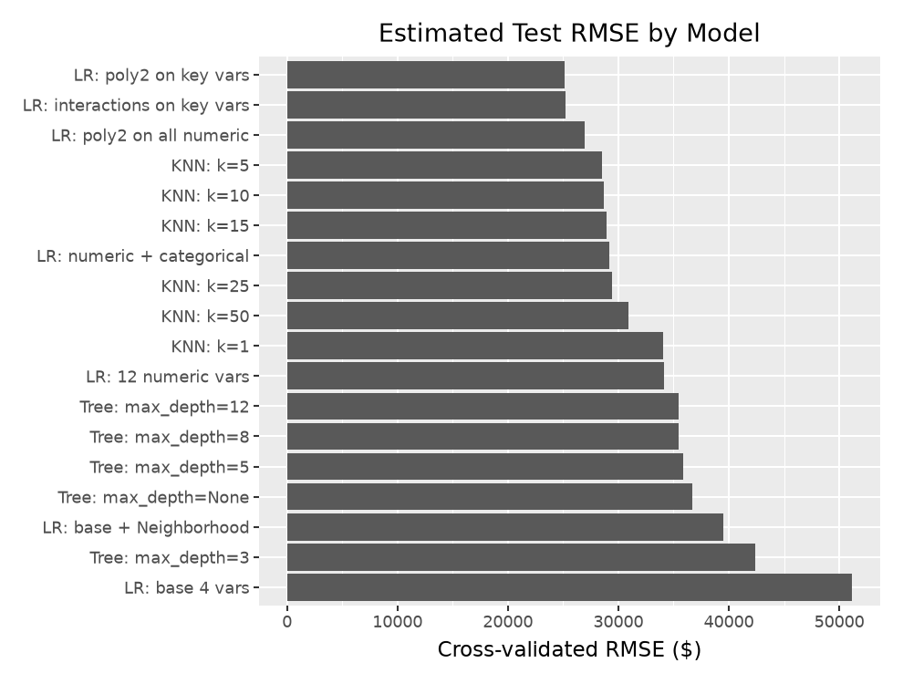

```python
(ggplot(df_results, aes(x="reorder(model, -cv_rmse)", y="cv_rmse"))
 + geom_col()
 + coord_flip()
 + labs(x="", y="Cross-validated RMSE ($)", title="Estimated Test RMSE by Model"))
```

### Conclusion

Conclusion My best model was a linear regression with 12 numeric predictors, 6 categorical predictors (Neighborhood, Kitchen Qual, Exter Qual, Bsmt Qual, MS Zoning, and Sale Condition), and degree-2 polynomial terms for the five strongest predictors: Overall Qual, Gr Liv Area, Total Bsmt SF, Garage Cars, and Year Built.

Its cross-validated RMSE was approximately $25,100, compared with approximately $51,200 for the original 4-variable model. For context, the standard deviation of SalePrice was about $80,000.

A few takeaways:

- Adding more relevant predictors, especially categorical ones like Neighborhood and quality ratings, made the biggest improvement.
- Polynomial terms helped most when applied only to the strongest predictors. Expanding all 12 numeric variables added many extra terms and did slightly worse.
- KNN did best around k = 5 to 10 (about $28,500). k = 1 overfit, and large k oversmoothed.
- Decision trees were the weakest (about $35,500 at best). A single tree is unstable, and depth beyond about 8 did not help.